# Generalized Additive Models in R

Doug Sponsler

11/18/2020

# Packages

```r
library(mgcv) # pretty much everything you need for GAM analysis
library(brms) # a Bayesian modeling package that includes wrappers for mgcv functions
library(tidyverse) # because I don't remember how to use base R
```

# Load and process data

These are honey bee colony weight data collected using data-logging hive scales. The context is a study of floral resource dynamics, inferred from colony weight dynamics, in the urban landscape of Philadelphia, Pennsylvania. See paper for details: https://esajournals.onlinelibrary.wiley.com/doi/full/10.1002/ecs2.3102

```r
data <- read_csv("./colony_weights.csv") %>% # read in data
  select(  # select and rename variables of interest
    timestamp = TimeStamp_round, # a datetime vector
    timestamp.unix = time, # a unix epoch time vector (units = seconds)
    scale.id = ScaleID, # a unique identifier for each hive/scale
    site, # 12 apiary locations
    weight = wt_recon_norm # cleaned and normalized colony weight
         ) %>%
  mutate(scale.id = factor(scale.id), site = factor(site)) # mgcv can only handle factors, not character vectors
```

# Visualize data

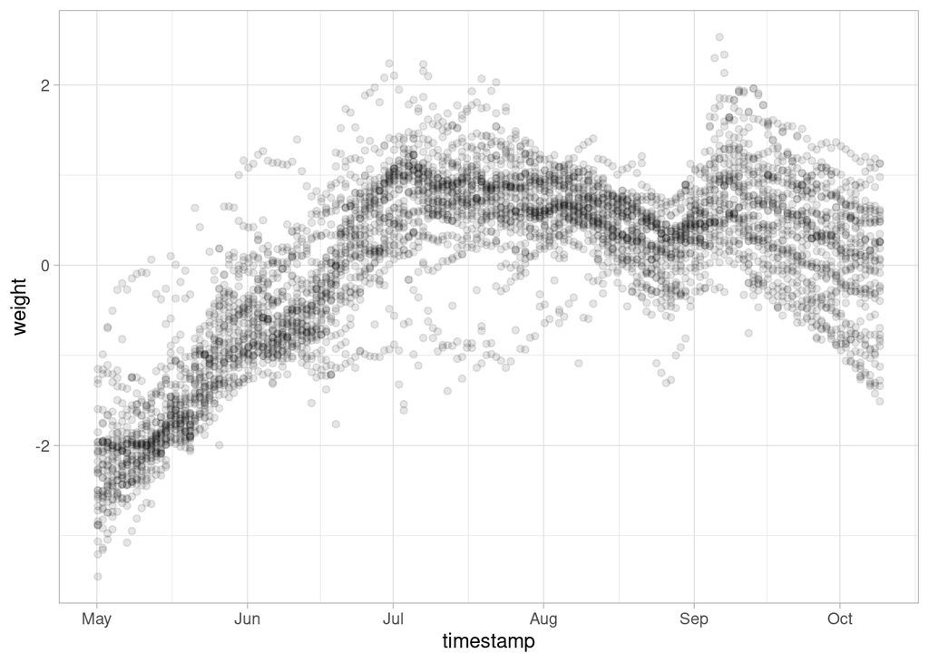

```r
ggplot(data, aes(timestamp, weight)) +
  geom_point(alpha = 0.1) + # set alpha to mitigate overplotting
  theme_light()
```

Fitting a straight line to these data is unsatisfying. Maybe a cubic polynomial? No, that is clearly underfitting. How many polynomial terms do we need? Well, an 8th-order polynomial seems to do a reasonable job of fitting the curves in our data, but:

1. High-order polynomial fits wiggle uninformatively at the high and low ends of the data
2. No sane person would fit an 8th-order polynomial to anything

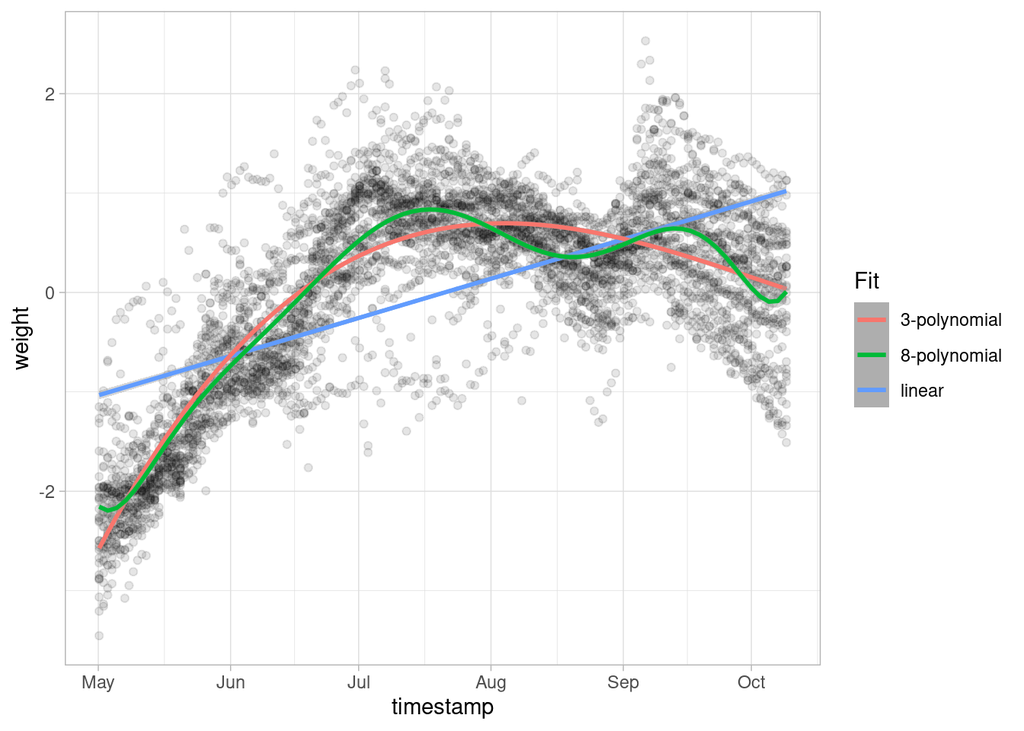

```r
ggplot(data, aes(timestamp, weight)) +
  geom_point(alpha = 0.1) +
  geom_smooth(method = "lm", aes(color = "linear")) + # linear fit
  geom_smooth(method = "lm", formula = y ~ poly(x, 3), aes(color = "3-polynomial")) + # 3rd order polynomial fit
  geom_smooth(method = "lm", formula = y ~ poly(x, 8), aes(color = "8-polynomial")) + # 8th order polynomial fit
  labs(color = "Fit") +
  theme_light()
```

As usual, though, ggplot has good defaults. If we don’t specify the smoothing method, geom_smooth() automatically fits a GAM to our data. Note how it captures the curves of the data while remaining stable at the high and low ends.

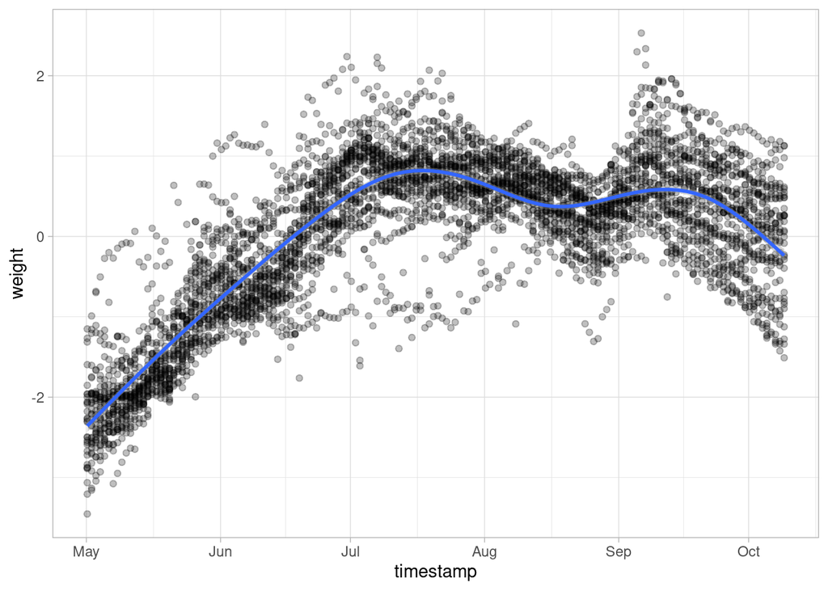

```r
ggplot(data, aes(timestamp, weight)) +
  geom_point(alpha = 0.25) +
  geom_smooth() +
  theme_light()
```